# Dirichlet Process Mixtures: Sensitivity to the prior on the precision parameter

Joon-Ho Lee (joonho@berkeley.edu)

March 11, 2020

# 1 The sensitivity of the Dirichlet process mixture model to the prior on the precision parameter

The Dirichlet process (DP) prior involves (1) a base distribution $G_{0}$, the expectation of $G$, and (2) a precision or strength parameter $\alpha_0$ governing the concentration of the prior for $G$ about its mean $G_{0}$. For any partition $A_1, ..., A_M$ on the support of $G_0$, the vector $\{G(A_1), ..., G(A_M)\}$ of probabilities $G(A_m)$ contained in the set $\{A_m, m = 1, ..., M\}$ follows a Dirichlet distribution $\text{Dirichlet}(\alpha_0 \cdot G_0(A_1), ..., \alpha_0 \cdot G_0(A_M))$.[^1]

Original forms of the DP prior assumed $G_0$ to be known and fixed. One problem with a Dirichlet Process when $G_0$ is known is that it assigns a probability of 1 to the space of discrete probablity measures, which means that site-level treatment effects $\{\hat{\tau}_k\}^{K}_{k=1}$ are measured exactly. An alternative is to take the parameters in $G_0$ to be unknown, and to follow a set of parametric distributions, with possibly unknown hyperparameters, resulting in a mixture of Dirichlet Process (MDP) model:

$$\hat{\tau}_{k} \sim N(\tau_{k}, \hat{se}_{k}^2) \quad \forall k,$$
$$\tau_{k} \sim \text{DP}(G_0, \alpha_0) \quad \forall k,$$

where $G_0 = N(\tau, \sigma_{\tau}^{2})$, $\tau \sim N(0, 100)$, and $\sigma_{\tau}^{-2} \sim \text{Gamma}(1, 1)$.

The precision parameter $\alpha_0$ can be considered as random, having a gamma distribution, $\alpha_0 \sim \text{Gamma}(a, b)$, or fixed at some particular value. But the literature on setting the standard prior on the clustering or precision parameter $\alpha$ in the Dirichlet process is limited. Escobar and West (1995) capture the uncertainty in $\alpha_0$ using a $\text{Gamma}(a, b)$ prior distribution with fixed hyperparameters $a$ and $b$. A general problem is that $a$ and $b$ may have a large impact on the posterior distribution of $\alpha_0$, and hence on the clustering behaviour, expecially under small sample sizes.

In this document, we vary the hyperparameters of the Gamma prior on $\alpha_0$ and examine the sensitivity of posterior inferences to the prior on the precision parameter $\alpha_0$. We are particularly interested in comparing the prior of $\alpha_0$ with the posterior of $\alpha_0$, in particular the prior and posterior variances, to see whether the data provide information on $\alpha_0$.

# 2 Simulation

We construct a loop over the informativeness of data (`rgt`) and the two choices for the $\text{Gamma}$ prior:

```r
### Define a vector of varying values of geometric mean
rgt_vec <- c(0.10, 0.33, 1.00)

### Define a list of multiple parameter choices for alpha
ab_list <- list(c(4, 4), c(10, 0.1))


### Generate a datafrmae for the loop reference
loop_ref <- expand.grid(seq_along(rgt_vec), seq_along(ab_list))
list_collect <- list()

for (i in seq(nrow(loop_ref))){

  ## Extract loop elements
  rgt <- rgt_vec[loop_ref[i, ][[1]]]
  alpha_param <- ab_list[[loop_ref[i, ][[2]]]]

  ### Generate sample draws from the mixture model
  set.seed(12345)
  df_G <- GenerateMdp(n = 50, rgt = rgt, rsr = 5)[c(1:3)] %>%
    data.frame() %>%
    rownames_to_column("K") %>%
    mutate_at(.vars = c("K"), .funs = as.numeric)

  ### Set MCMC parameters
  state <- NULL    # the current value of the parameters
  nburn <- 4000    # the number of burn-in scans
  nsave <- 4000    # the total number of scans to be saved
  nskip <- 20      # the thinning interval
  ndisplay <- 100  # the number of saved scans to be displayed on screen

  mcmc <- list(nburn = nburn, nsave = nsave,
               nskip = nskip, ndisplay = ndisplay)

  ### Set prior parameters
  prior <- list(a0 = alpha_param[1],  # alpha0: shape param.
                b0 = alpha_param[2],  # alpha0: rate param.
                tau1 = 1,   # G0 variance: shape param.
                tau2 = 1,   # G0 variance: rate param.
                mub = 0,
                Sb = 100)  # G0 mean: mean

  ### Prepare dataset as a matrix form (with y and sigma2)
  mat_DPmeta <- df_G %>% select(tau_k_hat, se_k2) %>% as.matrix()

  ### Estimate the Dirichlet Process model using DPpackage
  outp <- DPmeta(formula = mat_DPmeta ~ 1,
                 prior = prior, mcmc = mcmc,
                 state = state, status = TRUE)

  ### Save the output
  list_collect[[i]] <- outp

} ### End of loop
```

Then, we collect and tidy up the posterior samples from the estimation:

```r
### Define a function to tidy up the DPmeta objects
get_posterior_DPmeta <- function(outp = outp, nburn = 4000){

  # (1) Tidy up the "theta" output object
  df_theta <- outp$save.state$randsave %>%
    data.frame() %>%
    dplyr::select(-Prediction) %>%
    slice(c((nburn/2 + 1):nburn))  # throw away burn-ins
  colnames(df_theta) <- paste0("tau_k[", seq(ncol(df_theta)), "]")

  # (2) Tidy up the G0 parameters (m, s2), alpha0, and N of clusters outputs
  df_hyperparm <- outp$save.state$thetasave %>%
    data.frame() %>%
    dplyr::select(-tau_k_hat) %>%
    rename(G0_mu = mu, G0_s2 = sigma2, Ncluster = ncluster, alpha0 = alpha) %>%
    dplyr::select(G0_mu, G0_s2, alpha0, Ncluster) %>%
    slice(c((nburn/2 + 1):nburn))  # throw away burn-ins

  # Return the resulting object
  cbind.data.frame(df_hyperparm, df_theta)
}

### Collect posterior samples per each simulation setting
meta_list <- list()
for (i in seq(nrow(loop_ref))){

  ## Extract loop elements
  rgt <- rgt_vec[loop_ref[i, ][[1]]]
  alpha_param <- ab_list[[loop_ref[i, ][[2]]]]

  ##  Get posterior samples
  meta_list[[i]] <- get_posterior_DPmeta(list_collect[[i]], nburn) %>%
    mutate(rgt = paste0("rgt = ", sprintf("%.2f", rgt)),
           alpha_prior = paste0("gamma(", alpha_param[1], ", ",
                                alpha_param[2], ")")) %>%
    dplyr::select(rgt, alpha_prior, everything())
}

df_combine <- bind_rows(meta_list) %>%
  mutate(rgt = factor(rgt, levels =  paste0("rgt = ", sprintf("%.2f", rgt_vec))),
         alpha_prior = factor(alpha_prior,
                              levels = c("gamma(4, 4)", "gamma(10, 0.1)")))
```

```r
dim(df_combine)
```

```
## [1] 12000    56
```

# 3 Comparing the prior of $\alpha_0$ with the posterior of $\alpha_0$

We draw the samples from the $\text{Gamma}$ priors for the $\alpha_0$:

```r
### (1) alpha ~ gamma(4, 4)
set.seed(12345)
gm_prior1 <- rgamma(n = 2000, shape = 4, rate = 4)
mean(gm_prior1); sd(gm_prior1)
```

```
## [1] 0.9967467
```

```
## [1] 0.4936742
```

```r
### (2) alpha ~ gamma(10, 0.1)
set.seed(12345)
gm_prior2 <- rgamma(n = 2000, shape = 10, rate = 0.1)
mean(gm_prior2); sd(gm_prior2)
```

```
## [1] 100.1827
```

```
## [1] 31.47667
```

Next, we compare the prior of $\alpha_0$ with the posterior of $\alpha_0$:

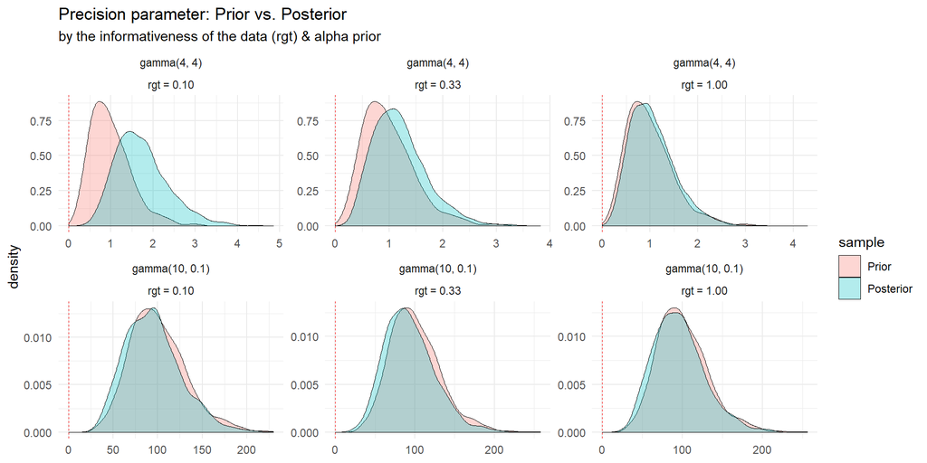

```r
###' Generate a dataframe to plot: Bind gamma prior samples
Prior <- c(rep(gm_prior1, times = 3), rep(gm_prior2, times = 3))

df_plot <- df_combine %>%
  dplyr::select(rgt, alpha_prior, alpha0) %>%
  arrange(alpha_prior, rgt) %>%
  rename(Posterior = alpha0) %>%
  cbind.data.frame(Prior) %>%
  gather(key = sample, value = value, Prior, Posterior) %>%
  mutate(sample = factor(sample, levels = c("Prior", "Posterior")))

### Plot
title <- c("Precision parameter: Prior vs. Posterior")
subtitle <- c("by the informativeness of the data (rgt) & alpha prior")
ggplot(data = df_plot, aes(x = value, group = sample, fill = sample)) +
  geom_density(position = "identity", size = 0.1, alpha = 0.3) +
  geom_vline(aes(xintercept = 0), size = 0.3, color = "red", linetype = "dashed") +
  labs(title = title, subtitle = subtitle, x = NULL) + theme_preset +
  facet_wrap(alpha_prior ~ rgt, scales = "free") +
  theme_minimal()
```

# 4 Comparison of posterior samples

## 4.1 Hyperparameters $\tau$ and $\sigma_{\tau}$

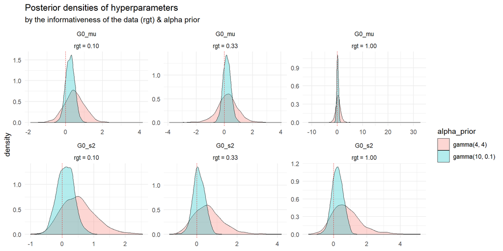

```r
### Generate a dataframe to plot
df_plot <- df_combine %>%
  dplyr::select(rgt, alpha_prior, G0_mu, G0_s2) %>%
  mutate(G0_s2 = log(G0_s2)) %>%    # Log-transformation for G0_s2
  gather(key = variable, value = value, G0_mu, G0_s2) %>%
  mutate(variable = factor(variable, levels = c("G0_mu", "G0_s2")))

### Plot
title <- c("Posterior densities of hyperparameters")
subtitle <- c("by the informativeness of the data (rgt) & alpha prior")

ggplot(data = df_plot, aes(x = value, group = alpha_prior, fill = alpha_prior)) +
  geom_density(position = "identity", size = 0.1, alpha = 0.3) +
  geom_vline(aes(xintercept = 0), size = 0.3, color = "red", linetype = "dashed") +
  labs(title = title, subtitle = subtitle, x = NULL) + theme_preset +
  facet_wrap(variable ~ rgt, scales = "free") +
  theme_minimal()
```

## 4.2 The number of clusters

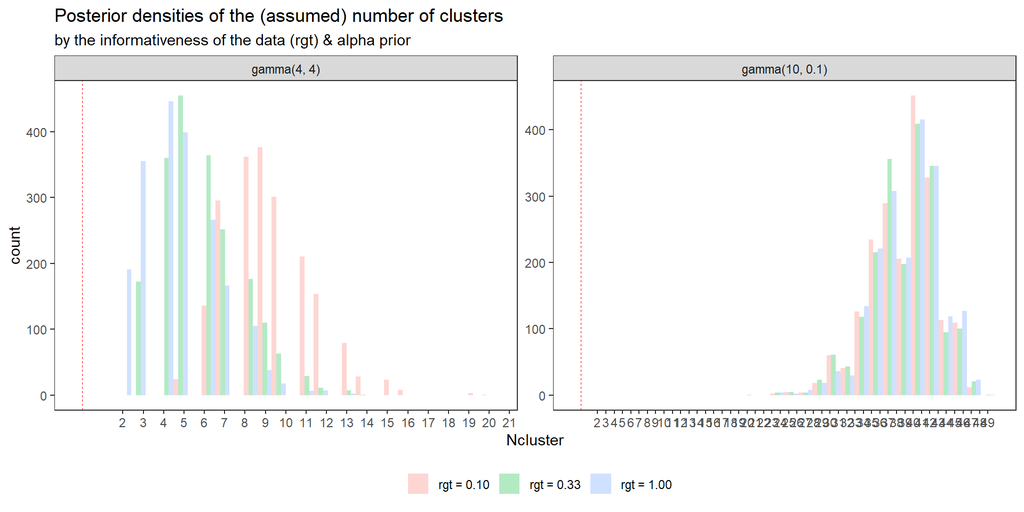

```r
### Generate a dataframe to plot
df_plot <- df_combine %>%
  dplyr::select(rgt, alpha_prior, Ncluster)

### Plot!
title <- c("Posterior densities of the (assumed) number of clusters")
ggplot(data = df_plot, aes(x = Ncluster, group = rgt, fill = rgt)) +
  geom_histogram(position = "dodge", size = 1, alpha = 0.3) +
  geom_vline(aes(xintercept = 0), size = 0.3, color = "red", linetype = "dashed") +
  labs(title = title, subtitle = subtitle) + theme_preset +
  facet_wrap(~ alpha_prior, scales = "free") +
  scale_x_continuous(breaks = min(df_plot$Ncluster):max(df_plot$Ncluster))
```

## 4.3 Empirical distribution function (EDF) estimates for $\tau_{k}$s

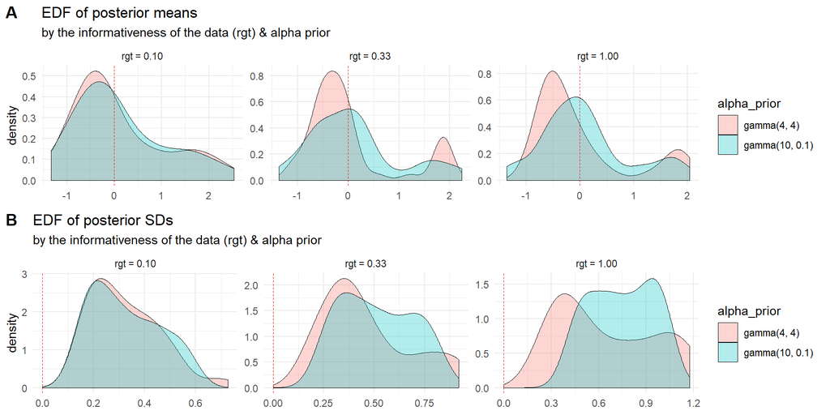

```r
### Generate a dataframe to plot
df_plot <- df_combine %>%
  dplyr::select(rgt, alpha_prior, contains("tau_k[")) %>%
  gather(key = variable, value = value, -rgt, -alpha_prior) %>%
  group_by(rgt, alpha_prior, variable) %>%
  summarise(mean = mean(value, na.rm = TRUE),
            sd = sd(value, na.rm = TRUE)) %>%
  mutate(id = as.numeric(str_extract(variable, "\\d+"))) %>%
  arrange(rgt, alpha_prior, id)

### Plot!
p1 <- ggplot(data = df_plot %>% rename(value = mean),
             aes(x = value, group = alpha_prior, fill = alpha_prior)) +
  geom_density(position = "identity", size = 0.1, alpha = 0.3) +
  geom_vline(aes(xintercept = 0), size = 0.3, color = "red", linetype = "dashed") +
  labs(title = "EDF of posterior means", subtitle = subtitle, x = NULL) + theme_preset +
  facet_wrap(. ~ rgt, scales = "free") +
  theme_minimal()

p2 <- ggplot(data = df_plot %>% rename(value = sd),
             aes(x = value, group = alpha_prior, fill = alpha_prior)) +
  geom_density(position = "identity", size = 0.1, alpha = 0.3) +
  geom_vline(aes(xintercept = 0), size = 0.3, color = "red", linetype = "dashed") +
  labs(title = "EDF of posterior SDs", subtitle = subtitle, x = NULL) + theme_preset +
  facet_wrap(. ~ rgt, scales = "free") +
  theme_minimal()

plot_grid(p1, p2, nrow = 2, labels = "AUTO")
```

## 4.4 Site-specific individual effect estimates $\tau_{k}$s

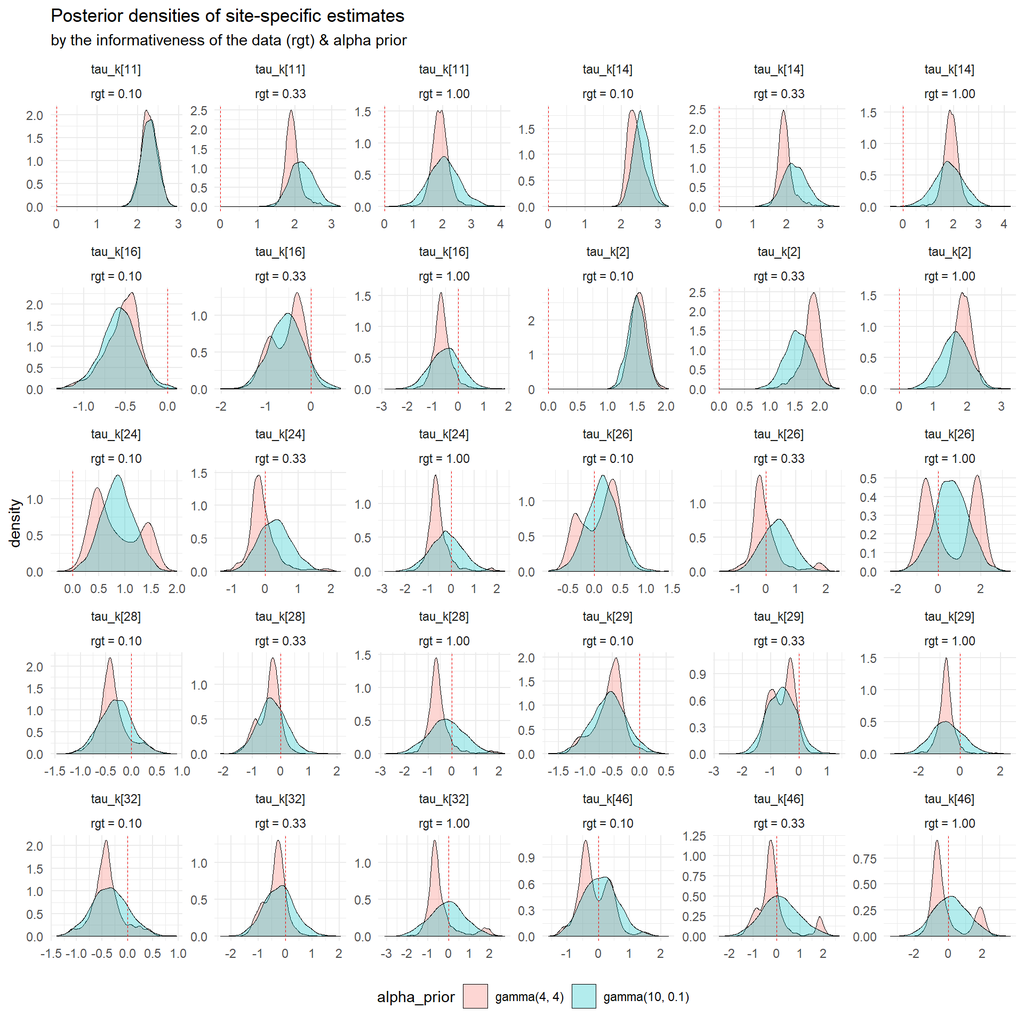

```r
### Randomly sample 10 sites
set.seed(12345)
rand_var <- paste0("tau_k[", sample(1:50, 10, replace = FALSE), "]")

### Generate a dataframe to plot
df_plot <- df_combine %>%
  dplyr::select(rgt, alpha_prior, rand_var) %>%
  gather(key = variable, value = value, -rgt, -alpha_prior)

### Plot
title <- "Posterior densities of site-specific estimates"
ggplot(data = df_plot, aes(x = value, group = alpha_prior, fill = alpha_prior)) +
  geom_density(position = "identity", size = 0.1, alpha = 0.3) +
  geom_vline(aes(xintercept = 0), size = 0.3, color = "red", linetype = "dashed") +
  labs(title = title, subtitle = subtitle, x = NULL) +
  facet_wrap(variable ~ rgt, scales = "free") +
  theme_minimal() + theme(legend.position = "bottom")
```

# References

Escobar, Michael D, and Mike West. 1995. “Bayesian Density Estimation and Inference Using Mixtures.” *Journal of the American Statistical Association* 90 (430): 577–88.

[^1]: Such an approach may be termed *semiparametric* as it involves a parametric model at the first level for the observations, but a nonparametric model at the second-level.